# Risk Factor Analysis

## Outcome Variable

**Outcome Variable:** wast_rec90d

## Predictor Variables

**Intervention Variable:** gagebrth

**Adjustment Set:**

- arm
- sex
- W_mage
- meducyrs
- feducyrs
- hhwealth_quart
- W_nrooms
- W_nchldlt5
- brthmon
- W_parity
- impsan
- delta_W_mage
- delta_meducyrs
- delta_feducyrs
- delta_hhwealth_quart
- delta_W_nrooms
- delta_W_nchldlt5
- delta_brthmon
- delta_W_parity
- delta_impsan

## Stratifying Variables

The analysis was stratified on these variable(s):

- agecat
- studyid
- country

## Data Summary

| agecat | studyid | country | gagebrth | wast_rec90d | n_cell | n |
| --- | --- | --- | --- | --- | --- | --- |
| 0-24 months | CMC-V-BCS-2002 | INDIA | Full or late term | 0 | 68 | 299 |
| 0-24 months | CMC-V-BCS-2002 | INDIA | Full or late term | 1 | 117 | 299 |
| 0-24 months | CMC-V-BCS-2002 | INDIA | Preterm | 0 | 21 | 299 |
| 0-24 months | CMC-V-BCS-2002 | INDIA | Preterm | 1 | 28 | 299 |
| 0-24 months | CMC-V-BCS-2002 | INDIA | Early term | 0 | 21 | 299 |
| 0-24 months | CMC-V-BCS-2002 | INDIA | Early term | 1 | 44 | 299 |
| 0-24 months | COHORTS | GUATEMALA | Full or late term | 0 | 66 | 280 |
| 0-24 months | COHORTS | GUATEMALA | Full or late term | 1 | 75 | 280 |
| 0-24 months | COHORTS | GUATEMALA | Preterm | 0 | 35 | 280 |
| 0-24 months | COHORTS | GUATEMALA | Preterm | 1 | 19 | 280 |
| 0-24 months | COHORTS | GUATEMALA | Early term | 0 | 46 | 280 |
| 0-24 months | COHORTS | GUATEMALA | Early term | 1 | 39 | 280 |
| 0-24 months | COHORTS | INDIA | Full or late term | 0 | 163 | 523 |
| 0-24 months | COHORTS | INDIA | Full or late term | 1 | 46 | 523 |
| 0-24 months | COHORTS | INDIA | Preterm | 0 | 96 | 523 |
| 0-24 months | COHORTS | INDIA | Preterm | 1 | 38 | 523 |
| 0-24 months | COHORTS | INDIA | Early term | 0 | 127 | 523 |
| 0-24 months | COHORTS | INDIA | Early term | 1 | 53 | 523 |
| 0-24 months | COHORTS | PHILIPPINES | Full or late term | 0 | 219 | 1675 |
| 0-24 months | COHORTS | PHILIPPINES | Full or late term | 1 | 352 | 1675 |
| 0-24 months | COHORTS | PHILIPPINES | Preterm | 0 | 156 | 1675 |
| 0-24 months | COHORTS | PHILIPPINES | Preterm | 1 | 238 | 1675 |
| 0-24 months | COHORTS | PHILIPPINES | Early term | 0 | 285 | 1675 |
| 0-24 months | COHORTS | PHILIPPINES | Early term | 1 | 425 | 1675 |
| 0-24 months | IRC | INDIA | Full or late term | 0 | 92 | 382 |
| 0-24 months | IRC | INDIA | Full or late term | 1 | 134 | 382 |
| 0-24 months | IRC | INDIA | Preterm | 0 | 24 | 382 |
| 0-24 months | IRC | INDIA | Preterm | 1 | 29 | 382 |
| 0-24 months | IRC | INDIA | Early term | 0 | 39 | 382 |
| 0-24 months | IRC | INDIA | Early term | 1 | 64 | 382 |

[output cut: 150 more lines]

The following strata were considered:

- agecat: 0-24 months, studyid: CMC-V-BCS-2002, country: INDIA
- agecat: 0-24 months, studyid: COHORTS, country: GUATEMALA
- agecat: 0-24 months, studyid: COHORTS, country: INDIA
- agecat: 0-24 months, studyid: COHORTS, country: PHILIPPINES
- agecat: 0-24 months, studyid: IRC, country: INDIA
- agecat: 0-24 months, studyid: JiVitA-3, country: BANGLADESH
- agecat: 0-24 months, studyid: Keneba, country: GAMBIA
- agecat: 0-24 months, studyid: NIH-Crypto, country: BANGLADESH
- agecat: 0-24 months, studyid: PROBIT, country: BELARUS
- agecat: 0-24 months, studyid: TanzaniaChild2, country: TANZANIA, UNITED REPUBLIC OF
- agecat: 0-6 months, studyid: CMC-V-BCS-2002, country: INDIA
- agecat: 0-6 months, studyid: COHORTS, country: GUATEMALA
- agecat: 0-6 months, studyid: COHORTS, country: INDIA
- agecat: 0-6 months, studyid: COHORTS, country: PHILIPPINES
- agecat: 0-6 months, studyid: IRC, country: INDIA
- agecat: 0-6 months, studyid: JiVitA-3, country: BANGLADESH
- agecat: 0-6 months, studyid: Keneba, country: GAMBIA
- agecat: 0-6 months, studyid: NIH-Crypto, country: BANGLADESH
- agecat: 0-6 months, studyid: PROBIT, country: BELARUS
- agecat: 0-6 months, studyid: TanzaniaChild2, country: TANZANIA, UNITED REPUBLIC OF
- agecat: 6-24 months, studyid: CMC-V-BCS-2002, country: INDIA
- agecat: 6-24 months, studyid: COHORTS, country: GUATEMALA
- agecat: 6-24 months, studyid: COHORTS, country: INDIA
- agecat: 6-24 months, studyid: COHORTS, country: PHILIPPINES
- agecat: 6-24 months, studyid: IRC, country: INDIA
- agecat: 6-24 months, studyid: JiVitA-3, country: BANGLADESH
- agecat: 6-24 months, studyid: Keneba, country: GAMBIA
- agecat: 6-24 months, studyid: NIH-Crypto, country: BANGLADESH
- agecat: 6-24 months, studyid: PROBIT, country: BELARUS
- agecat: 6-24 months, studyid: TanzaniaChild2, country: TANZANIA, UNITED REPUBLIC OF

### Dropped Strata

Some strata were dropped due to rare outcomes:

- agecat: 0-6 months, studyid: NIH-Crypto, country: BANGLADESH
- agecat: 6-24 months, studyid: COHORTS, country: GUATEMALA
- agecat: 6-24 months, studyid: COHORTS, country: INDIA
- agecat: 6-24 months, studyid: JiVitA-3, country: BANGLADESH
- agecat: 6-24 months, studyid: NIH-Crypto, country: BANGLADESH
- agecat: 6-24 months, studyid: PROBIT, country: BELARUS

## Methods Detail

We’re interested in the causal parameters $E[Y_a]$ for all values of $a \in \mathcal{A}$. These parameters represent the mean outcome if, possibly contrary to fact, we intervened to set all units to have $A=a$. Under the randomization and positivity assumptions, these are identified by the statistical parameters $\psi_a=E_W[E_{Y|A,W}(Y|A=a,W)]$. In addition, we’re interested in the mean of $Y$, $E[Y]$ under no intervention (the observed mean). We will estimate these parameters by using SuperLearner to fit the relevant likelihood factors – $E_{Y|A,W}(Y|A=a,W)$ and $p(A=a|W)$, and then updating our likelihood fit using a joint TMLE.

For unadjusted analyses ($W=\{\}$), initial likelihoods were estimated using Lrnr_glm to estimate the simple $E(Y|A)$ and Lrnr_mean to estimate $p(A)$. For adjusted analyses, a small library containing Lrnr_glmnet, Lrnr_xgboost, and Lrnr_mean was used.

Having estimated these parameters, we will then use the delta method to estimate relative risks and attributable risks relative to a prespecified baseline level of $A$.

# Results Detail

## Results Plots

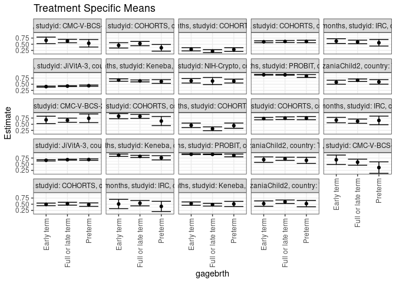

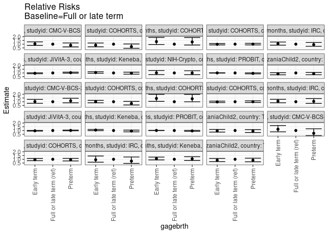

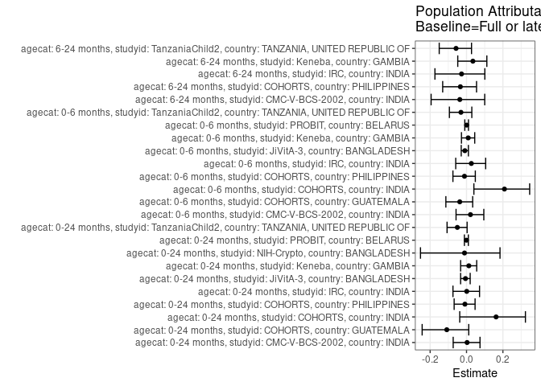

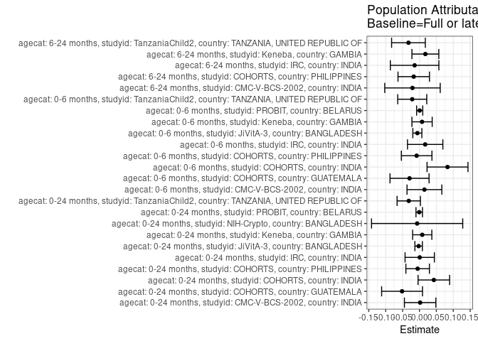

## Results Table

### Parameter: TSM

| agecat | studyid | country | intervention_level | baseline_level | estimate | ci_lower | ci_upper |
| --- | --- | --- | --- | --- | --- | --- | --- |
| 0-24 months | CMC-V-BCS-2002 | INDIA | Full or late term | NA | 0.6301174 | 0.5602343 | 0.7000005 |
| 0-24 months | CMC-V-BCS-2002 | INDIA | Preterm | NA | 0.5388680 | 0.3866768 | 0.6910592 |
| 0-24 months | CMC-V-BCS-2002 | INDIA | Early term | NA | 0.6570944 | 0.5249943 | 0.7891945 |
| 0-24 months | COHORTS | GUATEMALA | Full or late term | NA | 0.5265209 | 0.4401682 | 0.6128736 |
| 0-24 months | COHORTS | GUATEMALA | Preterm | NA | 0.3555351 | 0.2207093 | 0.4903609 |
| 0-24 months | COHORTS | GUATEMALA | Early term | NA | 0.4538677 | 0.3459151 | 0.5618202 |
| 0-24 months | COHORTS | INDIA | Full or late term | NA | 0.2193770 | 0.1598502 | 0.2789039 |
| 0-24 months | COHORTS | INDIA | Preterm | NA | 0.2839355 | 0.2078151 | 0.3600560 |
| 0-24 months | COHORTS | INDIA | Early term | NA | 0.2946466 | 0.2287035 | 0.3605898 |
| 0-24 months | COHORTS | PHILIPPINES | Full or late term | NA | 0.6113416 | 0.5679802 | 0.6547029 |
| 0-24 months | COHORTS | PHILIPPINES | Preterm | NA | 0.6116653 | 0.5619058 | 0.6614249 |
| 0-24 months | COHORTS | PHILIPPINES | Early term | NA | 0.5999726 | 0.5624355 | 0.6375097 |
| 0-24 months | IRC | INDIA | Full or late term | NA | 0.5935269 | 0.5214146 | 0.6656391 |
| 0-24 months | IRC | INDIA | Preterm | NA | 0.5588787 | 0.4261706 | 0.6915867 |
| 0-24 months | IRC | INDIA | Early term | NA | 0.6267625 | 0.5309593 | 0.7225658 |
| 0-24 months | JiVitA-3 | BANGLADESH | Full or late term | NA | 0.4239860 | 0.4081124 | 0.4398596 |
| 0-24 months | JiVitA-3 | BANGLADESH | Preterm | NA | 0.4393560 | 0.4143198 | 0.4643921 |
| 0-24 months | JiVitA-3 | BANGLADESH | Early term | NA | 0.4035880 | 0.3818568 | 0.4253191 |
| 0-24 months | Keneba | GAMBIA | Full or late term | NA | 0.6346956 | 0.5951815 | 0.6742097 |
| 0-24 months | Keneba | GAMBIA | Preterm | NA | 0.6105655 | 0.5343466 | 0.6867844 |
| 0-24 months | Keneba | GAMBIA | Early term | NA | 0.6688489 | 0.6196014 | 0.7180963 |
| 0-24 months | NIH-Crypto | BANGLADESH | Full or late term | NA | 0.6294979 | 0.4855324 | 0.7734635 |
| 0-24 months | NIH-Crypto | BANGLADESH | Preterm | NA | 0.6269827 | 0.5499007 | 0.7040646 |
| 0-24 months | NIH-Crypto | BANGLADESH | Early term | NA | 0.6381376 | 0.5477317 | 0.7285434 |
| 0-24 months | PROBIT | BELARUS | Full or late term | NA | 0.8813673 | 0.8678953 | 0.8948392 |
| 0-24 months | PROBIT | BELARUS | Preterm | NA | 0.8323962 | 0.7740945 | 0.8906979 |
| 0-24 months | PROBIT | BELARUS | Early term | NA | 0.8837657 | 0.8700621 | 0.8974693 |
| 0-24 months | TanzaniaChild2 | TANZANIA, UNITED REPUBLIC OF | Full or late term | NA | 0.6608508 | 0.6101579 | 0.7115438 |
| 0-24 months | TanzaniaChild2 | TANZANIA, UNITED REPUBLIC OF | Preterm | NA | 0.5952031 | 0.5033532 | 0.6870531 |
| 0-24 months | TanzaniaChild2 | TANZANIA, UNITED REPUBLIC OF | Early term | NA | 0.5819782 | 0.5010112 | 0.6629453 |
| 0-6 months | CMC-V-BCS-2002 | INDIA | Full or late term | NA | 0.6610169 | 0.5757140 | 0.7463199 |
| 0-6 months | CMC-V-BCS-2002 | INDIA | Preterm | NA | 0.7407407 | 0.5666423 | 0.9148392 |
| 0-6 months | CMC-V-BCS-2002 | INDIA | Early term | NA | 0.6750000 | 0.5258441 | 0.8241559 |
| 0-6 months | COHORTS | GUATEMALA | Full or late term | NA | 0.8181818 | 0.7368393 | 0.8995243 |
| 0-6 months | COHORTS | GUATEMALA | Preterm | NA | 0.6296296 | 0.4457667 | 0.8134926 |
| 0-6 months | COHORTS | GUATEMALA | Early term | NA | 0.8260870 | 0.7207224 | 0.9314515 |
| 0-6 months | COHORTS | INDIA | Full or late term | NA | 0.3152164 | 0.2387638 | 0.3916690 |
| 0-6 months | COHORTS | INDIA | Preterm | NA | 0.4414841 | 0.3346341 | 0.5483341 |
| 0-6 months | COHORTS | INDIA | Early term | NA | 0.4549244 | 0.3629513 | 0.5468974 |
| 0-6 months | COHORTS | PHILIPPINES | Full or late term | NA | 0.7449007 | 0.6899910 | 0.7998104 |
| 0-6 months | COHORTS | PHILIPPINES | Preterm | NA | 0.7471977 | 0.6822513 | 0.8121440 |
| 0-6 months | COHORTS | PHILIPPINES | Early term | NA | 0.7275226 | 0.6783128 | 0.7767325 |
| 0-6 months | IRC | INDIA | Full or late term | NA | 0.6222222 | 0.5361698 | 0.7082747 |
| 0-6 months | IRC | INDIA | Preterm | NA | 0.6538462 | 0.4797295 | 0.8279628 |
| 0-6 months | IRC | INDIA | Early term | NA | 0.6666667 | 0.5568093 | 0.7765240 |
| 0-6 months | JiVitA-3 | BANGLADESH | Full or late term | NA | 0.6830851 | 0.6641137 | 0.7020566 |
| 0-6 months | JiVitA-3 | BANGLADESH | Preterm | NA | 0.6879839 | 0.6588717 | 0.7170961 |
| 0-6 months | JiVitA-3 | BANGLADESH | Early term | NA | 0.6583359 | 0.6314707 | 0.6852011 |
| 0-6 months | Keneba | GAMBIA | Full or late term | NA | 0.8157592 | 0.7718196 | 0.8596987 |
| 0-6 months | Keneba | GAMBIA | Preterm | NA | 0.7592356 | 0.6734349 | 0.8450364 |
| 0-6 months | Keneba | GAMBIA | Early term | NA | 0.8638161 | 0.8160102 | 0.9116221 |
| 0-6 months | PROBIT | BELARUS | Full or late term | NA | 0.9002501 | 0.8873744 | 0.9131257 |
| 0-6 months | PROBIT | BELARUS | Preterm | NA | 0.8554091 | 0.7994694 | 0.9113489 |
| 0-6 months | PROBIT | BELARUS | Early term | NA | 0.9051982 | 0.8922810 | 0.9181154 |
| 0-6 months | TanzaniaChild2 | TANZANIA, UNITED REPUBLIC OF | Full or late term | NA | 0.7208005 | 0.6557652 | 0.7858358 |
| 0-6 months | TanzaniaChild2 | TANZANIA, UNITED REPUBLIC OF | Preterm | NA | 0.6564335 | 0.5304682 | 0.7823988 |
| 0-6 months | TanzaniaChild2 | TANZANIA, UNITED REPUBLIC OF | Early term | NA | 0.6848341 | 0.5731127 | 0.7965555 |
| 6-24 months | CMC-V-BCS-2002 | INDIA | Full or late term | NA | 0.5820896 | 0.4594727 | 0.7047064 |
| 6-24 months | CMC-V-BCS-2002 | INDIA | Preterm | NA | 0.3636364 | 0.1308138 | 0.5964590 |
| 6-24 months | CMC-V-BCS-2002 | INDIA | Early term | NA | 0.6800000 | 0.4890151 | 0.8709849 |
| 6-24 months | COHORTS | PHILIPPINES | Full or late term | NA | 0.5185680 | 0.4604362 | 0.5766998 |
| 6-24 months | COHORTS | PHILIPPINES | Preterm | NA | 0.4824859 | 0.4118758 | 0.5530961 |
| 6-24 months | COHORTS | PHILIPPINES | Early term | NA | 0.4927007 | 0.4403669 | 0.5450344 |
| 6-24 months | IRC | INDIA | Full or late term | NA | 0.5407023 | 0.4316788 | 0.6497259 |
| 6-24 months | IRC | INDIA | Preterm | NA | 0.4107199 | 0.2036543 | 0.6177856 |
| 6-24 months | IRC | INDIA | Early term | NA | 0.5085310 | 0.3208440 | 0.6962180 |
| 6-24 months | Keneba | GAMBIA | Full or late term | NA | 0.4810654 | 0.4247807 | 0.5373500 |
| 6-24 months | Keneba | GAMBIA | Preterm | NA | 0.5093741 | 0.4036142 | 0.6151341 |
| 6-24 months | Keneba | GAMBIA | Early term | NA | 0.5230017 | 0.4549623 | 0.5910412 |
| 6-24 months | TanzaniaChild2 | TANZANIA, UNITED REPUBLIC OF | Full or late term | NA | 0.5982858 | 0.5265355 | 0.6700360 |
| 6-24 months | TanzaniaChild2 | TANZANIA, UNITED REPUBLIC OF | Preterm | NA | 0.5230611 | 0.3960339 | 0.6500883 |
| 6-24 months | TanzaniaChild2 | TANZANIA, UNITED REPUBLIC OF | Early term | NA | 0.5247442 | 0.4152511 | 0.6342373 |

### Parameter: E(Y)

| agecat | studyid | country | intervention_level | baseline_level | estimate | ci_lower | ci_upper |
| --- | --- | --- | --- | --- | --- | --- | --- |
| 0-24 months | CMC-V-BCS-2002 | INDIA | NA | NA | 0.6321070 | 0.5744109 | 0.6898031 |
| 0-24 months | COHORTS | GUATEMALA | NA | NA | 0.4750000 | 0.4147665 | 0.5352335 |
| 0-24 months | COHORTS | INDIA | NA | NA | 0.2619503 | 0.2237649 | 0.3001357 |
| 0-24 months | COHORTS | PHILIPPINES | NA | NA | 0.6059701 | 0.5813402 | 0.6306001 |
| 0-24 months | IRC | INDIA | NA | NA | 0.5942408 | 0.5412823 | 0.6471994 |
| 0-24 months | JiVitA-3 | BANGLADESH | NA | NA | 0.4215278 | 0.4101272 | 0.4329284 |
| 0-24 months | Keneba | GAMBIA | NA | NA | 0.6429143 | 0.6145621 | 0.6712666 |
| 0-24 months | NIH-Crypto | BANGLADESH | NA | NA | 0.6225806 | 0.5684562 | 0.6767051 |
| 0-24 months | PROBIT | BELARUS | NA | NA | 0.8806715 | 0.8711794 | 0.8901636 |
| 0-24 months | TanzaniaChild2 | TANZANIA, UNITED REPUBLIC OF | NA | NA | 0.6291291 | 0.5901846 | 0.6680736 |
| 0-6 months | CMC-V-BCS-2002 | INDIA | NA | NA | 0.6756757 | 0.6074152 | 0.7439361 |
| 0-6 months | COHORTS | GUATEMALA | NA | NA | 0.7888199 | 0.7258783 | 0.8517615 |
| 0-6 months | COHORTS | INDIA | NA | NA | 0.3982558 | 0.3464489 | 0.4500628 |
| 0-6 months | COHORTS | PHILIPPINES | NA | NA | 0.7365591 | 0.7047881 | 0.7683302 |
| 0-6 months | IRC | INDIA | NA | NA | 0.6391304 | 0.5756367 | 0.7026242 |
| 0-6 months | JiVitA-3 | BANGLADESH | NA | NA | 0.6768510 | 0.6631621 | 0.6905400 |
| 0-6 months | Keneba | GAMBIA | NA | NA | 0.8234234 | 0.7927195 | 0.8541273 |
| 0-6 months | PROBIT | BELARUS | NA | NA | 0.9008671 | 0.8918443 | 0.9098900 |
| 0-6 months | TanzaniaChild2 | TANZANIA, UNITED REPUBLIC OF | NA | NA | 0.6993671 | 0.6481378 | 0.7505964 |
| 6-24 months | CMC-V-BCS-2002 | INDIA | NA | NA | 0.5614035 | 0.4645960 | 0.6582110 |
| 6-24 months | COHORTS | PHILIPPINES | NA | NA | 0.5016112 | 0.4676556 | 0.5355667 |
| 6-24 months | IRC | INDIA | NA | NA | 0.5263158 | 0.4415211 | 0.6111105 |
| 6-24 months | Keneba | GAMBIA | NA | NA | 0.4985591 | 0.4587425 | 0.5383757 |
| 6-24 months | TanzaniaChild2 | TANZANIA, UNITED REPUBLIC OF | NA | NA | 0.5657143 | 0.5118874 | 0.6195411 |

### Parameter: RR

| agecat | studyid | country | intervention_level | baseline_level | estimate | ci_lower | ci_upper |
| --- | --- | --- | --- | --- | --- | --- | --- |
| 0-24 months | CMC-V-BCS-2002 | INDIA | Full or late term | Full or late term | 1.0000000 | 1.0000000 | 1.000000 |
| 0-24 months | CMC-V-BCS-2002 | INDIA | Preterm | Full or late term | 0.8551866 | 0.6310607 | 1.158913 |
| 0-24 months | CMC-V-BCS-2002 | INDIA | Early term | Full or late term | 1.0428126 | 0.8299538 | 1.310263 |
| 0-24 months | COHORTS | GUATEMALA | Full or late term | Full or late term | 1.0000000 | 1.0000000 | 1.000000 |
| 0-24 months | COHORTS | GUATEMALA | Preterm | Full or late term | 0.6752535 | 0.4458544 | 1.022682 |
| 0-24 months | COHORTS | GUATEMALA | Early term | Full or late term | 0.8620126 | 0.6464455 | 1.149464 |
| 0-24 months | COHORTS | INDIA | Full or late term | Full or late term | 1.0000000 | 1.0000000 | 1.000000 |
| 0-24 months | COHORTS | INDIA | Preterm | Full or late term | 1.2942809 | 0.8838649 | 1.895271 |
| 0-24 months | COHORTS | INDIA | Early term | Full or late term | 1.3431061 | 0.9452178 | 1.908485 |
| 0-24 months | COHORTS | PHILIPPINES | Full or late term | Full or late term | 1.0000000 | 1.0000000 | 1.000000 |
| 0-24 months | COHORTS | PHILIPPINES | Preterm | Full or late term | 1.0005296 | 0.8983573 | 1.114322 |
| 0-24 months | COHORTS | PHILIPPINES | Early term | Full or late term | 0.9814033 | 0.8929487 | 1.078620 |
| 0-24 months | IRC | INDIA | Full or late term | Full or late term | 1.0000000 | 1.0000000 | 1.000000 |
| 0-24 months | IRC | INDIA | Preterm | Full or late term | 0.9416232 | 0.7211225 | 1.229547 |
| 0-24 months | IRC | INDIA | Early term | Full or late term | 1.0559970 | 0.8682851 | 1.284290 |
| 0-24 months | JiVitA-3 | BANGLADESH | Full or late term | Full or late term | 1.0000000 | 1.0000000 | 1.000000 |
| 0-24 months | JiVitA-3 | BANGLADESH | Preterm | Full or late term | 1.0362511 | 0.9680295 | 1.109281 |
| 0-24 months | JiVitA-3 | BANGLADESH | Early term | Full or late term | 0.9518897 | 0.8915307 | 1.016335 |
| 0-24 months | Keneba | GAMBIA | Full or late term | Full or late term | 1.0000000 | 1.0000000 | 1.000000 |
| 0-24 months | Keneba | GAMBIA | Preterm | Full or late term | 0.9619815 | 0.8368237 | 1.105858 |
| 0-24 months | Keneba | GAMBIA | Early term | Full or late term | 1.0538104 | 0.9571597 | 1.160221 |
| 0-24 months | NIH-Crypto | BANGLADESH | Full or late term | Full or late term | 1.0000000 | 1.0000000 | 1.000000 |
| 0-24 months | NIH-Crypto | BANGLADESH | Preterm | Full or late term | 0.9960044 | 0.7679742 | 1.291742 |
| 0-24 months | NIH-Crypto | BANGLADESH | Early term | Full or late term | 1.0137246 | 0.7746528 | 1.326578 |
| 0-24 months | PROBIT | BELARUS | Full or late term | Full or late term | 1.0000000 | 1.0000000 | 1.000000 |
| 0-24 months | PROBIT | BELARUS | Preterm | Full or late term | 0.9444374 | 0.8790985 | 1.014633 |
| 0-24 months | PROBIT | BELARUS | Early term | Full or late term | 1.0027213 | 0.9811238 | 1.024794 |
| 0-24 months | TanzaniaChild2 | TANZANIA, UNITED REPUBLIC OF | Full or late term | Full or late term | 1.0000000 | 1.0000000 | 1.000000 |
| 0-24 months | TanzaniaChild2 | TANZANIA, UNITED REPUBLIC OF | Preterm | Full or late term | 0.9006618 | 0.7580152 | 1.070152 |
| 0-24 months | TanzaniaChild2 | TANZANIA, UNITED REPUBLIC OF | Early term | Full or late term | 0.8806499 | 0.7512692 | 1.032312 |
| 0-6 months | CMC-V-BCS-2002 | INDIA | Full or late term | Full or late term | 1.0000000 | 1.0000000 | 1.000000 |
| 0-6 months | CMC-V-BCS-2002 | INDIA | Preterm | Full or late term | 1.1206078 | 0.8570471 | 1.465219 |
| 0-6 months | CMC-V-BCS-2002 | INDIA | Early term | Full or late term | 1.0211538 | 0.7906029 | 1.318937 |
| 0-6 months | COHORTS | GUATEMALA | Full or late term | Full or late term | 1.0000000 | 1.0000000 | 1.000000 |
| 0-6 months | COHORTS | GUATEMALA | Preterm | Full or late term | 0.7695473 | 0.5652821 | 1.047624 |
| 0-6 months | COHORTS | GUATEMALA | Early term | Full or late term | 1.0096618 | 0.8589016 | 1.186885 |
| 0-6 months | COHORTS | INDIA | Full or late term | Full or late term | 1.0000000 | 1.0000000 | 1.000000 |
| 0-6 months | COHORTS | INDIA | Preterm | Full or late term | 1.4005747 | 0.9936190 | 1.974207 |
| 0-6 months | COHORTS | INDIA | Early term | Full or late term | 1.4432130 | 1.0525790 | 1.978819 |
| 0-6 months | COHORTS | PHILIPPINES | Full or late term | Full or late term | 1.0000000 | 1.0000000 | 1.000000 |
| 0-6 months | COHORTS | PHILIPPINES | Preterm | Full or late term | 1.0030835 | 0.8949100 | 1.124333 |
| 0-6 months | COHORTS | PHILIPPINES | Early term | Full or late term | 0.9766706 | 0.8836805 | 1.079446 |
| 0-6 months | IRC | INDIA | Full or late term | Full or late term | 1.0000000 | 1.0000000 | 1.000000 |
| 0-6 months | IRC | INDIA | Preterm | Full or late term | 1.0508242 | 0.7784047 | 1.418583 |
| 0-6 months | IRC | INDIA | Early term | Full or late term | 1.0714286 | 0.8640328 | 1.328606 |
| 0-6 months | JiVitA-3 | BANGLADESH | Full or late term | Full or late term | 1.0000000 | 1.0000000 | 1.000000 |
| 0-6 months | JiVitA-3 | BANGLADESH | Preterm | Full or late term | 1.0071715 | 0.9575539 | 1.059360 |
| 0-6 months | JiVitA-3 | BANGLADESH | Early term | Full or late term | 0.9637684 | 0.9174068 | 1.012473 |
| 0-6 months | Keneba | GAMBIA | Full or late term | Full or late term | 1.0000000 | 1.0000000 | 1.000000 |
| 0-6 months | Keneba | GAMBIA | Preterm | Full or late term | 0.9307105 | 0.8213821 | 1.054591 |
| 0-6 months | Keneba | GAMBIA | Early term | Full or late term | 1.0589107 | 0.9802562 | 1.143876 |
| 0-6 months | PROBIT | BELARUS | Full or late term | Full or late term | 1.0000000 | 1.0000000 | 1.000000 |
| 0-6 months | PROBIT | BELARUS | Preterm | Full or late term | 0.9501906 | 0.8886648 | 1.015976 |
| 0-6 months | PROBIT | BELARUS | Early term | Full or late term | 1.0054964 | 0.9853831 | 1.026020 |
| 0-6 months | TanzaniaChild2 | TANZANIA, UNITED REPUBLIC OF | Full or late term | Full or late term | 1.0000000 | 1.0000000 | 1.000000 |
| 0-6 months | TanzaniaChild2 | TANZANIA, UNITED REPUBLIC OF | Preterm | Full or late term | 0.9107007 | 0.7372064 | 1.125025 |
| 0-6 months | TanzaniaChild2 | TANZANIA, UNITED REPUBLIC OF | Early term | Full or late term | 0.9501022 | 0.7897100 | 1.143070 |
| 6-24 months | CMC-V-BCS-2002 | INDIA | Full or late term | Full or late term | 1.0000000 | 1.0000000 | 1.000000 |
| 6-24 months | CMC-V-BCS-2002 | INDIA | Preterm | Full or late term | 0.6247086 | 0.3184160 | 1.225632 |
| 6-24 months | CMC-V-BCS-2002 | INDIA | Early term | Full or late term | 1.1682051 | 0.8223605 | 1.659495 |
| 6-24 months | COHORTS | PHILIPPINES | Full or late term | Full or late term | 1.0000000 | 1.0000000 | 1.000000 |
| 6-24 months | COHORTS | PHILIPPINES | Preterm | Full or late term | 0.9304198 | 0.7737998 | 1.118740 |
| 6-24 months | COHORTS | PHILIPPINES | Early term | Full or late term | 0.9501177 | 0.8141036 | 1.108856 |
| 6-24 months | IRC | INDIA | Full or late term | Full or late term | 1.0000000 | 1.0000000 | 1.000000 |
| 6-24 months | IRC | INDIA | Preterm | Full or late term | 0.7596045 | 0.4418140 | 1.305977 |
| 6-24 months | IRC | INDIA | Early term | Full or late term | 0.9405008 | 0.6152072 | 1.437795 |
| 6-24 months | Keneba | GAMBIA | Full or late term | Full or late term | 1.0000000 | 1.0000000 | 1.000000 |
| 6-24 months | Keneba | GAMBIA | Preterm | Full or late term | 1.0588460 | 0.8342941 | 1.343837 |
| 6-24 months | Keneba | GAMBIA | Early term | Full or late term | 1.0871739 | 0.9131885 | 1.294308 |
| 6-24 months | TanzaniaChild2 | TANZANIA, UNITED REPUBLIC OF | Full or late term | Full or late term | 1.0000000 | 1.0000000 | 1.000000 |
| 6-24 months | TanzaniaChild2 | TANZANIA, UNITED REPUBLIC OF | Preterm | Full or late term | 0.8742663 | 0.6666762 | 1.146496 |
| 6-24 months | TanzaniaChild2 | TANZANIA, UNITED REPUBLIC OF | Early term | Full or late term | 0.8770795 | 0.6892949 | 1.116022 |

### Parameter: PAR

| agecat | studyid | country | intervention_level | baseline_level | estimate | ci_lower | ci_upper |
| --- | --- | --- | --- | --- | --- | --- | --- |
| 0-24 months | CMC-V-BCS-2002 | INDIA | Full or late term | NA | 0.0019896 | -0.0445954 | 0.0485746 |
| 0-24 months | COHORTS | GUATEMALA | Full or late term | NA | -0.0515209 | -0.1120242 | 0.0089824 |
| 0-24 months | COHORTS | INDIA | Full or late term | NA | 0.0425732 | -0.0041105 | 0.0892570 |
| 0-24 months | COHORTS | PHILIPPINES | Full or late term | NA | -0.0053714 | -0.0402111 | 0.0294683 |
| 0-24 months | IRC | INDIA | Full or late term | NA | 0.0007140 | -0.0426524 | 0.0440803 |
| 0-24 months | JiVitA-3 | BANGLADESH | Full or late term | NA | -0.0024583 | -0.0135375 | 0.0086210 |
| 0-24 months | Keneba | GAMBIA | Full or late term | NA | 0.0082187 | -0.0201783 | 0.0366156 |
| 0-24 months | NIH-Crypto | BANGLADESH | Full or late term | NA | -0.0069173 | -0.1419427 | 0.1281082 |
| 0-24 months | PROBIT | BELARUS | Full or late term | NA | -0.0006958 | -0.0103006 | 0.0089091 |
| 0-24 months | TanzaniaChild2 | TANZANIA, UNITED REPUBLIC OF | Full or late term | NA | -0.0317217 | -0.0662238 | 0.0027804 |
| 0-6 months | CMC-V-BCS-2002 | INDIA | Full or late term | NA | 0.0146587 | -0.0368417 | 0.0661592 |
| 0-6 months | COHORTS | GUATEMALA | Full or late term | NA | -0.0293619 | -0.0871996 | 0.0284757 |
| 0-6 months | COHORTS | INDIA | Full or late term | NA | 0.0830394 | 0.0224316 | 0.1436472 |
| 0-6 months | COHORTS | PHILIPPINES | Full or late term | NA | -0.0083416 | -0.0536416 | 0.0369585 |
| 0-6 months | IRC | INDIA | Full or late term | NA | 0.0169082 | -0.0354403 | 0.0692567 |
| 0-6 months | JiVitA-3 | BANGLADESH | Full or late term | NA | -0.0062341 | -0.0195941 | 0.0071259 |
| 0-6 months | Keneba | GAMBIA | Full or late term | NA | 0.0076643 | -0.0223106 | 0.0376392 |
| 0-6 months | PROBIT | BELARUS | Full or late term | NA | 0.0006171 | -0.0084870 | 0.0097212 |
| 0-6 months | TanzaniaChild2 | TANZANIA, UNITED REPUBLIC OF | Full or late term | NA | -0.0214334 | -0.0643799 | 0.0215132 |
| 6-24 months | CMC-V-BCS-2002 | INDIA | Full or late term | NA | -0.0206860 | -0.1028182 | 0.0614461 |
| 6-24 months | COHORTS | PHILIPPINES | Full or late term | NA | -0.0169568 | -0.0635743 | 0.0296606 |
| 6-24 months | IRC | INDIA | Full or late term | NA | -0.0143866 | -0.0862557 | 0.0574826 |
| 6-24 months | Keneba | GAMBIA | Full or late term | NA | 0.0174937 | -0.0222931 | 0.0572805 |
| 6-24 months | TanzaniaChild2 | TANZANIA, UNITED REPUBLIC OF | Full or late term | NA | -0.0325715 | -0.0825072 | 0.0173643 |

### Parameter: PAF

| agecat | studyid | country | intervention_level | baseline_level | estimate | ci_lower | ci_upper |
| --- | --- | --- | --- | --- | --- | --- | --- |
| 0-24 months | CMC-V-BCS-2002 | INDIA | Full or late term | NA | 0.0031475 | -0.0733083 | 0.0741571 |
| 0-24 months | COHORTS | GUATEMALA | Full or late term | NA | -0.1084651 | -0.2439240 | 0.0122428 |
| 0-24 months | COHORTS | INDIA | Full or late term | NA | 0.1625242 | -0.0372467 | 0.3238197 |
| 0-24 months | COHORTS | PHILIPPINES | Full or late term | NA | -0.0088641 | -0.0680160 | 0.0470116 |
| 0-24 months | IRC | INDIA | Full or late term | NA | 0.0012015 | -0.0745214 | 0.0715882 |
| 0-24 months | JiVitA-3 | BANGLADESH | Full or late term | NA | -0.0058318 | -0.0324628 | 0.0201123 |
| 0-24 months | Keneba | GAMBIA | Full or late term | NA | 0.0127835 | -0.0323745 | 0.0559662 |
| 0-24 months | NIH-Crypto | BANGLADESH | Full or late term | NA | -0.0111107 | -0.2530455 | 0.1841120 |
| 0-24 months | PROBIT | BELARUS | Full or late term | NA | -0.0007900 | -0.0117560 | 0.0100571 |
| 0-24 months | TanzaniaChild2 | TANZANIA, UNITED REPUBLIC OF | Full or late term | NA | -0.0504216 | -0.1069806 | 0.0032476 |
| 0-6 months | CMC-V-BCS-2002 | INDIA | Full or late term | NA | 0.0216949 | -0.0575958 | 0.0950410 |
| 0-6 months | COHORTS | GUATEMALA | Full or late term | NA | -0.0372226 | -0.1135640 | 0.0338851 |
| 0-6 months | COHORTS | INDIA | Full or late term | NA | 0.2085078 | 0.0404619 | 0.3471234 |
| 0-6 months | COHORTS | PHILIPPINES | Full or late term | NA | -0.0113251 | -0.0747463 | 0.0483537 |
| 0-6 months | IRC | INDIA | Full or late term | NA | 0.0264550 | -0.0593125 | 0.1052784 |
| 0-6 months | JiVitA-3 | BANGLADESH | Full or late term | NA | -0.0092105 | -0.0291473 | 0.0103401 |
| 0-6 months | Keneba | GAMBIA | Full or late term | NA | 0.0093078 | -0.0277913 | 0.0450678 |
| 0-6 months | PROBIT | BELARUS | Full or late term | NA | 0.0006850 | -0.0094723 | 0.0107400 |
| 0-6 months | TanzaniaChild2 | TANZANIA, UNITED REPUBLIC OF | Full or late term | NA | -0.0306468 | -0.0940938 | 0.0291208 |
| 6-24 months | CMC-V-BCS-2002 | INDIA | Full or late term | NA | -0.0368470 | -0.1946251 | 0.1000928 |
| 6-24 months | COHORTS | PHILIPPINES | Full or late term | NA | -0.0338047 | -0.1310343 | 0.0550665 |
| 6-24 months | IRC | INDIA | Full or late term | NA | -0.0273345 | -0.1736512 | 0.1007413 |
| 6-24 months | Keneba | GAMBIA | Full or late term | NA | 0.0350885 | -0.0481612 | 0.1117262 |
| 6-24 months | TanzaniaChild2 | TANZANIA, UNITED REPUBLIC OF | Full or late term | NA | -0.0575758 | -0.1500873 | 0.0274941 |